# Test, adjust for, and report publication bias: a primer

Doing publication bias test in R: a Hands-on guide

# Instructions

This interactive format Rmarkdown/html is used to provide participants with a hands-on guide and R code, which can be directly adjusted to their own publication bias tests.

# Loading packages

Load the`R` packages used in this tutorial. The main `R` packages used in this tutorial are `metafor` (for model fitting; Viechtbauer (2010)) and `orchaRd` (for results reporting; Nakagawa et al. (2021)). All other `R` packages are used for data manipulations, visualizations and rmarkdown knitting.

```r
# the following packages are used for knitting, participants do not need to install and load them
pacman::p_load(knitr,
               DT,
               readxl,
               patchwork,
               ggplot2,
               pander,
               formatR,
               rmdformats
               )
```

Below we randomly choose one meta-analysis paper in Costello and Fox (2022)’s dataset as an example to show how to properly test, adjust for and report publication bias.

> Montagano L, Leroux S J, Giroux M A, et al. The strength of ecological subsidies across ecosystems: a latitudinal gradient of direct and indirect impacts on food webs[J]. Ecology Letters, 2019, 22(2): 265-274.

# Load and process data from the example paper

```r
# load package
library(readr) # package for reading data
library(tidyverse) # package for data manipulation
# load data
montagano.et.al.2019.ecol.letts.dat <- read_csv(file = "data/montagano.et.al.2019.ecol.letts.csv")

# have a look at the data
head(montagano.et.al.2019.ecol.letts.dat)
```

```
## # A tibble: 6 x 15
##   ID         Year Latitude Longitude Subs   System Taxon Effect2 Study n_subsidy
##   <chr>     <dbl>    <dbl>     <dbl> <chr>  <chr>  <chr> <chr>   <chr>     <dbl>
## 1 Adams_et~  2015     68.6   -150.   Nutri~ aquat~ other dir     expe~         3
## 2 Adams_et~  2015     68.6   -150.   Nutri~ aquat~ other dir     expe~         3
## 3 Adams_et~  2015     68.6   -150.   Nutri~ aquat~ other dir     expe~         3
## 4 Adams_et~  2015     68.6   -150.   Nutri~ aquat~ other dir     expe~         3
## 5 Aristi_e~  2016     42.0      2.84 Nutri~ aquat~ other dir     expe~         3
## 6 Aristi_e~  2016     42.0      2.84 Nutri~ aquat~ other dir     expe~         3
## # ... with 5 more variables: Subsidy_mean <dbl>, Subsidy_sd <dbl>,
## #   n_nosubsidy <dbl>, Nosubsidy_mean <dbl>, Nosubsidy_sd <dbl>
```

As shown in the slides, the extended Egger’s regression model looks complex, but it is not difficult to construct it using existing software, for example, `rma.mv()` function in `metafor` package.

```r
# load package
library(metafor) # package for performing meta-analysis
# compute effect size and its sampling variance
montagano.et.al.2019.ecol.letts.dat <- escalc(measure = "ROM",
                                              n1i = n_subsidy, n2i = n_nosubsidy,
                                              m1i = Subsidy_mean, m2i = Nosubsidy_mean,
                                              sd1i = Subsidy_sd, sd2i = Nosubsidy_sd,
                                              append=TRUE, replace=TRUE,
                                              data = montagano.et.al.2019.ecol.letts.dat)

# delete NAs
montagano.et.al.2019.ecol.letts.dat <- montagano.et.al.2019.ecol.letts.dat[!is.na(montagano.et.al.2019.ecol.letts.dat$yi) & !is.na(montagano.et.al.2019.ecol.letts.dat$vi), ]

# have a look at the data
t <- montagano.et.al.2019.ecol.letts.dat %>% DT::datatable()
t
```

|  | ID | Year | Latitude | Longitude | Subs | System | Taxon | Effect2 | Study | n_subsidy | Subsidy_mean | Subsidy_sd | n_nosubsidy | Nosubsidy_mean | Nosubsidy_sd | yi | vi |
| --- | --- | --- | --- | --- | --- | --- | --- | --- | --- | --- | --- | --- | --- | --- | --- | --- | --- |
| 1 | Adams_et_al.2015Frontiers_in_Microbiology | 2015 | 68.633333 | -149.6 | Nutrients | aquatic | other | dir | experimental | 3 | 5.445629587 | 1.455725908 | 3 | 4.237474309 | 2.092605992 | 0.250845966415287 | 0.105110449094267 |
| 2 | Adams_et_al.2015Frontiers_in_Microbiology | 2015 | 68.633333 | -149.6 | Nutrients | aquatic | other | dir | experimental | 3 | 4.025382574 | 0.606552462 | 3 | 3.254957475 | 0.283057816 | 0.212440744735547 | 0.01008914929232 |
| 3 | Adams_et_al.2015Frontiers_in_Microbiology | 2015 | 68.633333 | -149.6 | Nutrients | aquatic | other | dir | experimental | 3 | 5.06916996 | 0.889986581 | 3 | 2.915019763 | 0.479223544 | 0.553300488684501 | 0.0192836719087669 |
| 4 | Adams_et_al.2015Frontiers_in_Microbiology | 2015 | 68.633333 | -149.6 | Nutrients | aquatic | other | dir | experimental | 3 | 7.529644269 | 1.523246263 | 3 | 3.883399209 | 0.599029429 | 0.662136943972497 | 0.0215731702113854 |
| 5 | Aristi_et_al2016Environmental_Pollution | 2016 | 41.967303 | 2.84065 | Nutrients | aquatic | other | dir | experimental | 3 | 72.88732394 | 20.53252717 | 3 | 69.24882629 | 16.66997256 | 0.0512085449990655 | 0.0457683513295501 |
| 6 | Aristi_et_al2016Environmental_Pollution | 2016 | 41.967303 | 2.84065 | Nutrients | aquatic | other | dir | experimental | 3 | 76.17370892 | 5.692185753 | 3 | 69.24882629 | 16.66997256 | 0.0953101798174528 | 0.0211776325300571 |
| 7 | Barrett_et_al.2005Oikos | 2005 | 28.916667 | -113.5 | Marine_debris | terrestrial | vertebrate | asc | descriptive | 2 | 78.1 | 29.4156421 | 2 | 24.9 | 7.14177849 | 1.14312225337498 | 0.11206152608006 |
| 8 | Barrett_et_al.2005Oikos | 2005 | 28.916667 | -113.5 | Seabird_derived | terrestrial | vertebrate | asc | descriptive | 9 | 26.1 | 42.3 | 9 | 8.36 | 4.92 | 1.13847688723204 | 0.330331879909959 |
| 9 | Bartels_et_al.2012Oecologia | 2012 | 68.341944 | 19.156111 | Nutrients | aquatic | other | dir | experimental | 4 | 0.57 | 0.15 | 4 | 0.7 | 0.04 | -0.205443974214809 | 0.018129345921194 |
| 10 | Bartels_et_al.2012Oecologia | 2012 | 68.341944 | 19.156111 | Nutrients | aquatic | other | dir | experimental | 4 | 0.51 | 0.18 | 4 | 0.65 | 0.05 | -0.242561637171311 | 0.0326211584529391 |

[output cut: 559 more lines]

# Test publication bias (testing small-study effects and decline effects)

Recall the mathematical formulas used to test publication bias:

$$y_{i} = \beta_{0} + \beta_{1}se_{i} + \beta_{2}c(year_{j}) + \sum \beta_{k}x_{k} + \mu_{(b)j} + \mu_{(w)i} + m_{i}, \\ \mu_{(b)j} \sim N(0,\sigma_{(b)}^2)\\ \mu_{(w)i} \sim N(0,\sigma_{(w)}^2)\\ m_{i} \sim N(0,\nu_{i})$$

```r
# add an unique identifier to each row (effect size) to account for multiple effect sizes nested within the same studies
montagano.et.al.2019.ecol.letts.dat$obsID <- 1:nrow(montagano.et.al.2019.ecol.letts.dat)

# center publication year and other continuous moderator variables to ease interpretation of the results
## center year
montagano.et.al.2019.ecol.letts.dat$Year.c <- montagano.et.al.2019.ecol.letts.dat$Year - mean(montagano.et.al.2019.ecol.letts.dat$Year) # this variable will be used as a predictor to estimate decline effects
## center latitude
montagano.et.al.2019.ecol.letts.dat$Latitude.c <- montagano.et.al.2019.ecol.letts.dat$Latitude - mean(montagano.et.al.2019.ecol.letts.dat$Latitude)
## center altitude
montagano.et.al.2019.ecol.letts.dat$Longitude.c <- montagano.et.al.2019.ecol.letts.dat$Longitude - mean(montagano.et.al.2019.ecol.letts.dat$Longitude)

# create a variable to contain sampling error, which can be used as a predictor to identify small-study effect
montagano.et.al.2019.ecol.letts.dat$sei <- sqrt(montagano.et.al.2019.ecol.letts.dat$vi)

# simultaneously detect small-study effect and decline effect
pub_bias_test <- rma.mv(yi, vi,
                        random = list(~ 1 | ID, ~ 1 | obsID),
                        mods = ~ sei + Year.c +  Latitude.c + Longitude.c + System + Taxon + Taxon -1,
                        test = "t",
                        method = "REML",
                        data = montagano.et.al.2019.ecol.letts.dat) # Latitude,  Longitude,  System, Taxon and Taxon are moderator variables used in the original paper
```

Let’s have a look at the model results of the above fitted multilevel multi-moderator meta-regression with:

```r
summary(pub_bias_test)
```

```
##
## Multivariate Meta-Analysis Model (k = 569; method: REML)
##
##    logLik   Deviance        AIC        BIC       AICc
## -692.1974  1384.3947  1404.3947  1447.6919  1404.7947
##
## Variance Components:
##
##             estim    sqrt  nlvls  fixed  factor
## sigma^2.1  0.3128  0.5593     70     no      ID
## sigma^2.2  0.4746  0.6889    569     no   obsID
##
## Test for Residual Heterogeneity:
## QE(df = 561) = 36124.4658, p-val < .0001
##
## Test of Moderators (coefficients 1:8):
## F(df1 = 8, df2 = 561) = 8.4661, p-val < .0001
##
## Model Results:
##
##                    estimate      se     tval   df    pval    ci.lb   ci.ub
## sei                  0.6292  0.2032   3.0958  561  0.0021   0.2300  1.0283  **
## Year.c              -0.0245  0.0140  -1.7436  561  0.0818  -0.0521  0.0031   .
## Latitude.c          -0.0025  0.0038  -0.6407  561  0.5220  -0.0100  0.0051
## Longitude.c         -0.0005  0.0010  -0.4884  561  0.6255  -0.0025  0.0015
## Systemaquatic        0.4186  0.1356   3.0862  561  0.0021   0.1522  0.6849  **
## Systemterrestrial    0.4524  0.1422   3.1816  561  0.0015   0.1731  0.7317  **
## Taxonother          -0.1989  0.1245  -1.5982  561  0.1106  -0.4434  0.0456
## Taxonvertebrate      0.2051  0.1884   1.0887  561  0.2767  -0.1649  0.5751
##
## ---
## Signif. codes:  0 '***' 0.001 '**' 0.01 '*' 0.05 '.' 0.1 ' ' 1
```

# Report publication bias

We see that the model slope $\beta_{2}$ (`Year.c`) is not statistically significant, which indicates that there is no decline effect. Let’s visually present the results of the decline effect test (which can be done by `bubble_plot` in `orchaRd`; Nakagawa et al. (2021))

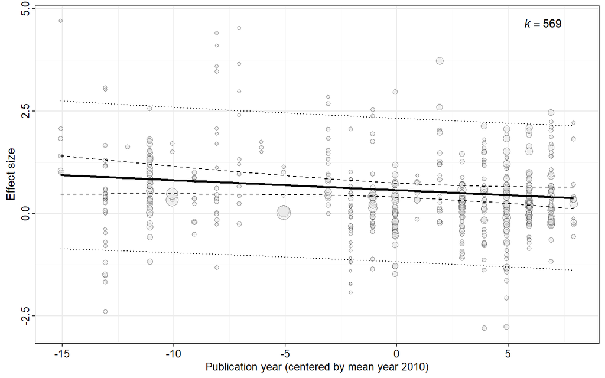

Figure 1. Bubble plot showing the relationship between publication year and effect size magnitude

```r
# load package
library(orchaRd) # package for visualizations of results of publication bias test
# you need to install the latest version via devtools::install_github("daniel1noble/orchaRd", force = TRUE, build_vignettes = TRUE)

de <- bubble_plot(pub_bias_test, mod = "Year.c",
                  xlab = "Publication year (centered by mean year 2010)", ylab = "Effect size",
                  group = "ID",
                  data = montagano.et.al.2019.ecol.letts.dat, legend.pos = "none") +
                  theme(axis.text.x = element_text(size = 10, colour = "black"),
                        axis.text.y = element_text(size = 10, colour = "black"),
                        axis.title.x = element_text(size = 10, colour = "black"),
                        plot.title = element_text(size = 10, colour = "black"))
de
```

We can see a temporal trend in the changes of the effect size magnitude (**Figure 1**). The estimate of slope $\beta_{2}$ is -0.0245 (95% CI = -0.0521 to 0.0031), indicating that the effect size magnitude will decline by 0.245 over 10 years. If we only focus on the dichotomous reports on the decline effect test (*p*-value < 0.05 meaning decline effect *vs.* *p*-value > 0.05 meaning no decline effect), we would neglect the real decline of the effect size magnitude.

The similar interpretation philosophy can be applied to the test of small-study effect. The model slope $\beta_{1}$ (`sei`) is statistically significant, which indicates that there is a small-study effect.

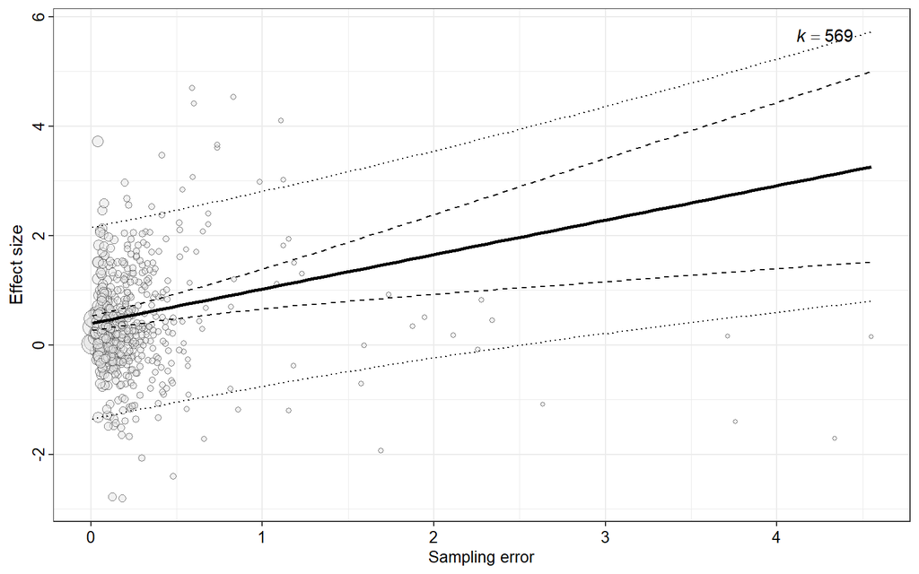

Figure 2. Bubble plot showing the relationship between sampling error (inverse precision) anf effect size magnitude

```r
sse <- bubble_plot(pub_bias_test, mod = "sei",
                   xlab = "Sampling error", ylab = "Effect size",
                   group = "ID",
                   data = montagano.et.al.2019.ecol.letts.dat, legend.pos = "none") +
                   theme(axis.text.x = element_text(size = 10, colour = "black"),
                         axis.text.y = element_text(size = 10, colour = "black"),
                         axis.title.x = element_text(size = 10, colour = "black"),
                         plot.title = element_text(size = 10, colour = "black"))
sse
```

The visual presentation of the model results also confirms that small studies (with low precision) are more likely to report large effects (**Figure 2**). The estimate of slope $\beta_{1}$ is very large 0.6292 (95% CI = 0.23 to 1.0283), implying that we should interpret the results and conclusions of Montagano et al. (2019) with caution.

We can also use a funnel plot (Figure 3) to visually check the asymmetry.

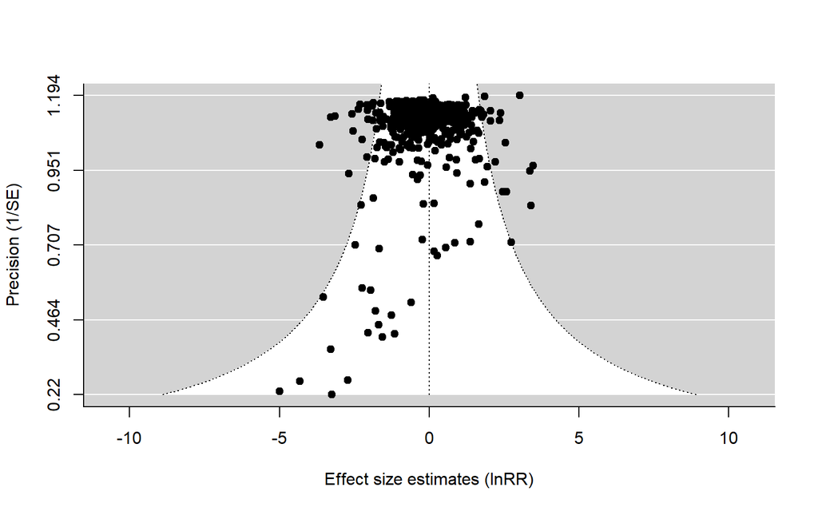

Figure 3. Visual inspection of the funnel plot to identify the small-study effect

```r
# make a funnel plot
funnel(pub_bias_test, yaxis = "seinv",
       ylab = "Precision (1/SE)",
       xlab = "Effect size estimates (lnRR)")
```

# Adjust for publication bias

Recall the mathematical formulas used to adjust for publication bias:

$$y_{i} = \beta_{0} + \beta_{1}se_{i}^2 + \beta_{2}c(year_{j}) + \sum \beta_{k}x_{k} + \mu_{(b)j} + \mu_{(w)i} + m_{i}, \\ \mu_{(b)j} \sim N(0,\sigma_{(b)}^2)\\ \mu_{(w)i} \sim N(0,\sigma_{(w)}^2)\\ m_{i} \sim N(0,\nu_{i})$$

```r
# fit the above formula
pub_bias_adjust <- rma.mv(yi, vi,
                          random = list(~ 1 | ID, ~ 1 | obsID),
                          mods = ~ vi + Year.c, # do not remove intercept via "-1", because intercept is our focal model estimate
                          test = "t",
                          method = "REML",
                          data = montagano.et.al.2019.ecol.letts.dat)
```

Let’s have a look at the model results of the above fitted multilevel multi-moderator meta-regression with:

```r
summary(pub_bias_adjust)
```

```
##
## Multivariate Meta-Analysis Model (k = 569; method: REML)
##
##    logLik   Deviance        AIC        BIC       AICc
## -706.1243  1412.2486  1422.2486  1443.9415  1422.3557
##
## Variance Components:
##
##             estim    sqrt  nlvls  fixed  factor
## sigma^2.1  0.3037  0.5511     70     no      ID
## sigma^2.2  0.4870  0.6979    569     no   obsID
##
## Test for Residual Heterogeneity:
## QE(df = 566) = 39682.2018, p-val < .0001
##
## Test of Moderators (coefficients 2:3):
## F(df1 = 2, df2 = 566) = 4.6487, p-val = 0.0099
##
## Model Results:
##
##          estimate      se     tval   df    pval    ci.lb    ci.ub
## intrcpt    0.5323  0.0808   6.5909  566  <.0001   0.3736   0.6909  ***
## vi         0.0929  0.0956   0.9710  566  0.3320  -0.0950   0.2807
## Year.c    -0.0369  0.0130  -2.8383  566  0.0047  -0.0625  -0.0114   **
##
## ---
## Signif. codes:  0 '***' 0.001 '**' 0.01 '*' 0.05 '.' 0.1 ' ' 1
```

We can see that the adjusted effect size is statistically significant ($\beta_{0}$ = 0.5323, 95%CI = [0.3736, 0.6909], p-value < 0.0001). By comparing the original effect size and the adjusted effect size (see below table), we know that although this meta-analysis has publication bias, the result is robust.

```r
# fit a intercept-only model to estimate the overall effect/pooled effect size
overall_effect_mod <- rma.mv(yi, vi,
                             random = list(~ 1 | ID, ~ 1 | obsID),
                             test = "t",
                             method = "REML",
                             data = montagano.et.al.2019.ecol.letts.dat)

# make a table to compare the original effect size and the adjusted effect size
t1 <- data.frame("Overall effect (pooled lnRR)" = c(round(overall_effect_mod$b[1],4), round(pub_bias_adjust$b[1],4)),
             "Standard error" = c(round(overall_effect_mod$se,4), round(pub_bias_adjust$se[1],4)),
             "p-value" = c(round(overall_effect_mod$pval,4), round(pub_bias_adjust$pval[1],4)),
             "Lower CI" = c(round(overall_effect_mod$ci.lb,4), round(pub_bias_adjust$ci.lb[1],4)),
             "Upper CI" = c(round(overall_effect_mod$ci.ub,4), round(pub_bias_adjust$ci.ub[1],4)))

colnames(t1) <- c("Overall effect (pooled lnRR)", "Standard error", "p-value", "Lower CI", "Upper CI")

t1_2 <- t(t1) %>% as.data.frame()
colnames(t1_2) <- c("Original estimate", "Bias-corrected version")

t1_2 %>% DT::datatable()
```

|  | Original estimate | Bias-corrected version |
| --- | --- | --- |
| Overall effect (pooled lnRR) | 0.5351 | 0.5323 |
| Standard error | 0.0846 | 0.0808 |
| p-value | 0 | 0 |
| Lower CI | 0.3689 | 0.3736 |
| Upper CI | 0.7012 | 0.6909 |

# Conduct your own analyses and further materials to learn

Participants can modify the above code to test and adjust for publication bias (small-study effect and decline effect) and (visually) report the associated results. If you prefer an `rmd` version of the code, please refer to our [Github repository: Yefeng0920/Publication_bias_workshop_SORTEE2022](https://github.com/Yefeng0920/Publication_bias_workshop_SORTEE2022). If you are after a comprehensive theoretical knowledge on the publication bias test in ecology and evolution, we recommend you to thoroughly read our recent methodological paper published in *Methods in Ecology and Evolution* (Nakagawa et al. (2022)). In this paper, we summarized the current practice of publication bias tests in ecology and evolution; we also proposed the multilevel multi-moderator meta-regression method approach.

# References

Costello, L., and J. W. Fox. 2022. Decline effects are rare in ecology. Ecology:e3680.

Montagano, L., S. J. Leroux, M.-A. Giroux, and N. Lecomte. 2019. The strength of ecological subsidies across ecosystems: A latitudinal gradient of direct and indirect impacts on food webs. Ecology letters 22:265–274.

Nakagawa, S., M. Lagisz, M. D. Jennions, J. Koricheva, D. W. Noble, T. H. Parker, A. Sánchez-Tójar, Y. Yang, and R. E. O’Dea. 2022. Methods for testing publication bias in ecological and evolutionary meta-analyses. Methods in Ecology and Evolution 13:4–21.

Nakagawa, S., M. Lagisz, R. E. O’Dea, J. Rutkowska, Y. Yang, D. W. Noble, and A. M. Senior. 2021. The orchard plot: Cultivating a forest plot for use in ecology, evolution, and beyond. Research Synthesis Methods 12:4–12.

Viechtbauer, W. 2010. Conducting meta-analyses in r with the metafor package. Journal of statistical software 36:1–48.